# TP Kaggle - Cover Type Prediction of Forests

### Use cartographic variables to classify forest categories.

Natural resource managers responsible for developing ecosystem management strategies require basic descriptive information including inventory data for forested lands to support their decision-making processes. However, managers generally do not have this type of data for inholdings or neighboring lands that are outside their immediate jurisdiction. One method of obtaining this information is through the use of predictive models.

The study area included four wilderness areas found in the Roosevelt National Forest of northern Colorado. A total of twelve cartographic measures were utilized as independent variables in the predictive models, while seven major forest cover types were used as dependent variables. Several subsets of these variables were examined to determine the best overall predictive model.

```python
# import libraries
import numpy as np
import pandas as pd
import matplotlib.pyplot as plt
from sklearn.ensemble import RandomForestClassifier, ExtraTreesClassifier
from sklearn.model_selection import train_test_split
from sklearn.metrics import accuracy_score

pd.set_option('display.max_columns', 60)
```

```python
# import files
train_df = pd.read_csv('C:/Users/Pascal/Desktop/Telecom ParisTech/Cours/SD701 - Big Data Mining/TP/TP KAGGLE/train-set.csv', index_col='Id')
test_df = pd.read_csv('C:/Users/Pascal/Desktop/Telecom ParisTech/Cours/SD701 - Big Data Mining/TP/TP KAGGLE/test-set.csv', index_col='Id')
```

### Data Description

Given is the attribute name, attribute type, the measurement unit and a brief description. The forest cover type is the classification problem. The order of this listing corresponds to the order of numerals along the rows of the database.

Name Data Type Measurement Description:

- Elevation quantitative meters Elevation in meters
- Aspect quantitative azimuth Aspect in degrees azimuth
- Slope quantitative degrees Slope in degrees
- Horizontal_Distance_To_Hydrology quantitative meters Horz Dist to nearest surface water features
- Vertical_Distance_To_Hydrology quantitative meters Vert Dist to nearest surface water features
- Horizontal_Distance_To_Roadways quantitative meters Horz Dist to nearest roadway
- Hillshade_9am quantitative 0 to 255 index Hillshade index at 9am, summer solstice
- Hillshade_Noon quantitative 0 to 255 index Hillshade index at noon, summer soltice
- Hillshade_3pm quantitative 0 to 255 index Hillshade index at 3pm, summer solstice
- Horizontal_Distance_To_Fire_Points quantitative meters Horz Dist to nearest wildfire ignition points
- Wilderness_Area (4 binary columns) qualitative 0 (absence) or 1 (presence) Wilderness area designation
- Soil_Type (40 binary columns) qualitative 0 (absence) or 1 (presence) Soil Type designation
- Cover_Type (7 types) integer 1 to 7 Forest Cover Type designation

Forest Cover Type Classes :

- 1 - Spruce/Fir
- 2 - Lodgepole Pine
- 3 - Ponderosa Pine
- 4 - Cottonwood/Willow
- 5 - Aspen
- 6 - Douglas-fir
- 7 - Krummholz

### Data Cleaning

```python
# Detect missing data
print("There is " + str(train_df[train_df.isnull().any(axis=1)].iloc[:,0].count())+ " value(s) missing.")
```

```
There is 0 value(s) missing.
```

### Data Exploration

```python
# Observe few rows of the dataset and his shape
print("Number of rows in the train dataset: " + str(train_df.iloc[:, 0].count()))
print("Number of columns in the train dataset: " + str(train_df.iloc[0, :].count()))
train_df.head(5)
```

```
Number of rows in the train dataset: 528720
Number of columns in the train dataset: 55
```

| Id | Elevation | Aspect | Slope | Horizontal_Distance_To_Hydrology | Vertical_Distance_To_Hydrology | Horizontal_Distance_To_Roadways | Hillshade_9am | Hillshade_Noon | Hillshade_3pm | Horizontal_Distance_To_Fire_Points | Wilderness_Area1 | Wilderness_Area2 | Wilderness_Area3 | Wilderness_Area4 | Soil_Type1 | Soil_Type2 | Soil_Type3 | Soil_Type4 | Soil_Type5 | Soil_Type6 | Soil_Type7 | Soil_Type8 | Soil_Type9 | Soil_Type10 | Soil_Type11 | Soil_Type12 | Soil_Type13 | Soil_Type14 | Soil_Type15 | … |
| --- | --- | --- | --- | --- | --- | --- | --- | --- | --- | --- | --- | --- | --- | --- | --- | --- | --- | --- | --- | --- | --- | --- | --- | --- | --- | --- | --- | --- | --- | --- |
| 1 | 2611 | 326 | 20 | 120 | 27 | 1597 | 168 | 214 | 184 | 2913 | 0 | 0 | 1 | 0 | 0 | 0 | 0 | 0 | 0 | 0 | 0 | 0 | 0 | 1 | 0 | 0 | 0 | 0 | 0 | … |
| 2 | 2772 | 324 | 17 | 42 | 7 | 1814 | 175 | 220 | 183 | 2879 | 1 | 0 | 0 | 0 | 0 | 0 | 0 | 0 | 0 | 0 | 0 | 0 | 0 | 0 | 0 | 0 | 0 | 0 | 0 | … |
| 3 | 2764 | 4 | 14 | 480 | -21 | 700 | 201 | 212 | 148 | 700 | 0 | 0 | 1 | 0 | 0 | 0 | 0 | 0 | 0 | 0 | 0 | 0 | 0 | 0 | 1 | 0 | 0 | 0 | 0 | … |
| 4 | 3032 | 342 | 9 | 60 | 8 | 4050 | 202 | 227 | 164 | 2376 | 1 | 0 | 0 | 0 | 0 | 0 | 0 | 0 | 0 | 0 | 0 | 0 | 0 | 0 | 0 | 0 | 0 | 0 | 0 | … |
| 5 | 2488 | 23 | 11 | 117 | 21 | 1117 | 209 | 218 | 151 | 1136 | 0 | 0 | 0 | 1 | 0 | 0 | 0 | 0 | 0 | 1 | 0 | 0 | 0 | 0 | 0 | 0 | 0 | 0 | 0 | … |

```python
# Change column position of the feature 'Horizontal_Distance_To_Fire_Points' close the other features corresponding to distances
def change_column_order(df, col_name, index):
    cols = df.columns.tolist()
    cols.remove(col_name)
    cols.insert(index, col_name)
    return df[cols]

train_df = change_column_order(train_df, 'Horizontal_Distance_To_Fire_Points', 6)
test_df = change_column_order(test_df, 'Horizontal_Distance_To_Fire_Points', 6)
```

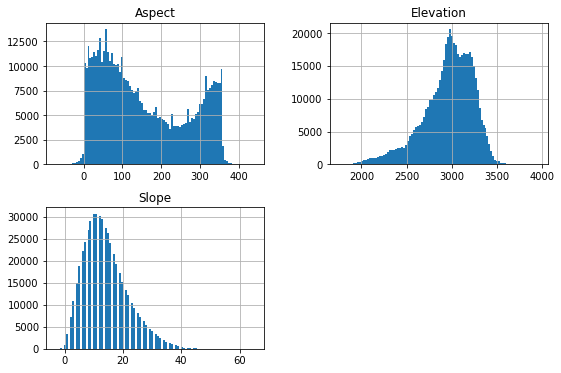

```python
# Explore the features linked to field aspect
train_df.iloc[:,:3].hist(figsize=(9,6), bins=100)
plt.show()
```

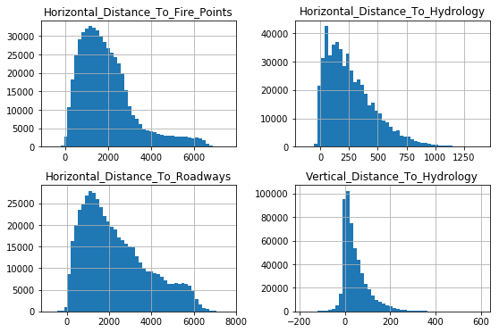

```python
# Explore the features linked to distances to commodities
train_df.iloc[:,3:7].hist(figsize=(9,6), bins=50)
plt.show()
```

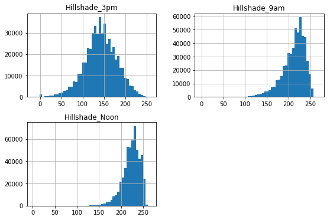

```python
# Explore the features linked to Hillshade
train_df.iloc[:,7:10].hist(figsize=(9,6), bins=50)
plt.show()
```

```python
# Explore the features linked to different types of wilderness areas
train_df.iloc[:,10:14].describe()
```

|  | Wilderness_Area1 | Wilderness_Area2 | Wilderness_Area3 | Wilderness_Area4 |
| --- | --- | --- | --- | --- |
| count | 528720.000000 | 528720.000000 | 528720.000000 | 528720.000000 |
| mean | 0.448795 | 0.051551 | 0.436255 | 0.063398 |
| std | 0.497372 | 0.221119 | 0.495920 | 0.243678 |
| min | 0.000000 | 0.000000 | 0.000000 | 0.000000 |
| 25% | 0.000000 | 0.000000 | 0.000000 | 0.000000 |
| 50% | 0.000000 | 0.000000 | 0.000000 | 0.000000 |
| 75% | 1.000000 | 0.000000 | 1.000000 | 0.000000 |
| max | 1.000000 | 1.000000 | 1.000000 | 1.000000 |

```python
# Explore the features linked to the different types of soil
summary_soil_type = train_df.iloc[:,14:-1].describe().transpose().sort_values(by=['mean'])
summary_soil_type.head(10)
```

|  | count | mean | std | min | 25% | 50% | 75% | max |
| --- | --- | --- | --- | --- | --- | --- | --- | --- |
| Soil_Type15 | 528720.0 | 0.000002 | 0.001375 | 0.0 | 0.0 | 0.0 | 0.0 | 1.0 |
| Soil_Type7 | 528720.0 | 0.000193 | 0.013888 | 0.0 | 0.0 | 0.0 | 0.0 | 1.0 |
| Soil_Type36 | 528720.0 | 0.000202 | 0.014224 | 0.0 | 0.0 | 0.0 | 0.0 | 1.0 |
| Soil_Type8 | 528720.0 | 0.000316 | 0.017770 | 0.0 | 0.0 | 0.0 | 0.0 | 1.0 |
| Soil_Type37 | 528720.0 | 0.000471 | 0.021696 | 0.0 | 0.0 | 0.0 | 0.0 | 1.0 |
| Soil_Type25 | 528720.0 | 0.000825 | 0.028705 | 0.0 | 0.0 | 0.0 | 0.0 | 1.0 |
| Soil_Type14 | 528720.0 | 0.001040 | 0.032236 | 0.0 | 0.0 | 0.0 | 0.0 | 1.0 |
| Soil_Type21 | 528720.0 | 0.001445 | 0.037986 | 0.0 | 0.0 | 0.0 | 0.0 | 1.0 |
| Soil_Type28 | 528720.0 | 0.001545 | 0.039279 | 0.0 | 0.0 | 0.0 | 0.0 | 1.0 |
| Soil_Type27 | 528720.0 | 0.001903 | 0.043579 | 0.0 | 0.0 | 0.0 | 0.0 | 1.0 |

```python
# Counting the appearance
print(train_df['Soil_Type15'].value_counts())
```

```
0    528719
1         1
Name: Soil_Type15, dtype: int64
```

By observing the mean column of the soil types, we notice that certain features are not represented that much. For example, 'Soil_Type15' appears only one time in 528720 observations.

### Features Selection

In this part, we will try to select the most important and relevant features.

To make this selection, we will choose the algorithms that we are going to use and check the weights of the different features.

In this study, we are going to use Random Forest Classifier and Extra Trees Classifier (we have already checked the performances of other algorithms but the most relevant were these two, so to simplify the study we will start directly with the two).

```python
# Create a sample dateset to train a first algorithm
# Here we try to fit with Extratrees Classifier but we have the same results with Random Forest classifer
X_sample, _, y_sample, _ = train_test_split(train_df.iloc[:, :-1].values,
                                            train_df.iloc[:, -1:].values.ravel(),
                                            test_size=0.7)

ex_sample = ExtraTreesClassifier(n_estimators=10)
ex_sample.fit(X_sample, y_sample.ravel())
```

```
ExtraTreesClassifier(bootstrap=False, class_weight=None, criterion='gini',
           max_depth=None, max_features='auto', max_leaf_nodes=None,
           min_impurity_decrease=0.0, min_impurity_split=None,
           min_samples_leaf=1, min_samples_split=2,
           min_weight_fraction_leaf=0.0, n_estimators=10, n_jobs=1,
           oob_score=False, random_state=None, verbose=0, warm_start=False)
```

```python
# Define a function to get the importances rank of the features from a certain algorithm
def importances_top10(estimator, col_array, title):
    importances = estimator.feature_importances_
    indices = np.argsort(importances)[::-1]
    print("%s Top 10 Important Features:\n" %title)
    for f in range(10):
        print("%d. %s (%f)" % (f + 1, col_array.columns[indices[f]], importances[indices[f]]))
    #Mean Feature Importance
    print("\nMean Features importances : %.6f" %np.mean(importances))
    #Plot the feature importances of the algorithm
    indices = indices[:10]
    plt.figure()
    plt.title(title+" Top 10 Rank Feature importances")
    plt.bar(range(10), importances[indices], color=[(1, 0.8, 0.5, 1),(1, 1, 0.5, 1)], align="center")
    plt.xticks(range(10), col_array.columns[indices], fontsize=14, rotation=90)
    plt.xlim([-1, 10])
    plt.show()

def importances_toplast10(estimator, col_array, title):
    importances = estimator.feature_importances_
    indices = np.argsort(importances)[::1]
    print("%s Top last 10 Important Features:\n" %title)
    for f in range(10):
        print("%d. %s (%f)" % (f + 1, col_array.columns[indices[f]], importances[indices[f]]))
    #Mean Feature Importance
    print("\nMean Features importances : %.6f" %np.mean(importances))
    #Plot the feature importances of the algorithm
    indices = indices[:10]
    plt.figure()
    plt.title(title+" Top last 10 Rank Feature importances")
    plt.bar(range(10), importances[indices], color=[(1, 0.8, 0.5, 1),(1, 1, 0.5, 1)], align="center")
    plt.xticks(range(10), col_array.columns[indices], fontsize=14, rotation=90)
    plt.xlim([-1, 10])
    plt.show()
```

```
Cover Type (Extratree Algorithm) Top 10 Important Features:

1. Elevation (0.177887)
2. Horizontal_Distance_To_Roadways (0.096431)
3. Horizontal_Distance_To_Fire_Points (0.094260)
4. Horizontal_Distance_To_Hydrology (0.064439)
5. Vertical_Distance_To_Hydrology (0.061269)
6. Aspect (0.056668)
7. Hillshade_Noon (0.053086)
8. Hillshade_9am (0.051432)
9. Hillshade_3pm (0.051095)
10. Slope (0.046586)

Mean Features importances : 0.018519
```

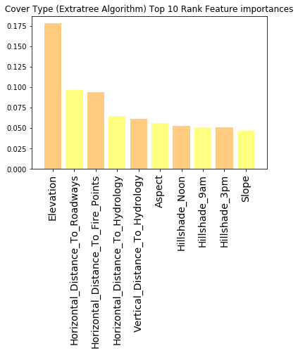

```
Cover Type (Extratree Algorithm) Top last 10 Important Features:

1. Soil_Type15 (0.000005)
2. Soil_Type7 (0.000037)
3. Soil_Type8 (0.000064)
4. Soil_Type36 (0.000121)
5. Soil_Type9 (0.000139)
6. Soil_Type28 (0.000333)
7. Soil_Type18 (0.000397)
8. Soil_Type25 (0.000463)
9. Soil_Type5 (0.000513)
10. Soil_Type37 (0.000595)

Mean Features importances : 0.018519
```

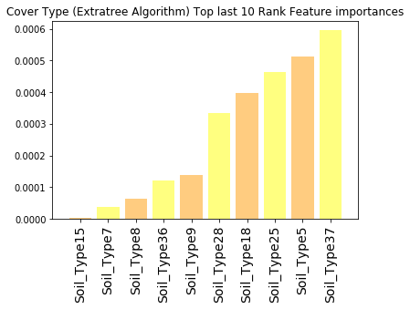

```python
# Display the importances of the features
importances_top10(ex_sample, train_df, "Cover Type (Extratree Algorithm)")
importances_toplast10(ex_sample, train_df, "Cover Type (Extratree Algorithm)")
```

We observe that the most important features for the algorithm (in this case Extratrees classification) are the cartographic features linked to aspect, distances to amenities and hillshade and the least important features are the soil types. This is coherent with the fact that there are a lot of types of soil and thus reduce the weight of every soil type features.

The list of features that are less impacting is correlated with the list of soil type features that are less represented in the data set :

```python
summary_soil_type.head(15)
```

|  | count | mean | std | min | 25% | 50% | 75% | max |
| --- | --- | --- | --- | --- | --- | --- | --- | --- |
| Soil_Type15 | 528720.0 | 0.000002 | 0.001375 | 0.0 | 0.0 | 0.0 | 0.0 | 1.0 |
| Soil_Type7 | 528720.0 | 0.000193 | 0.013888 | 0.0 | 0.0 | 0.0 | 0.0 | 1.0 |
| Soil_Type36 | 528720.0 | 0.000202 | 0.014224 | 0.0 | 0.0 | 0.0 | 0.0 | 1.0 |
| Soil_Type8 | 528720.0 | 0.000316 | 0.017770 | 0.0 | 0.0 | 0.0 | 0.0 | 1.0 |
| Soil_Type37 | 528720.0 | 0.000471 | 0.021696 | 0.0 | 0.0 | 0.0 | 0.0 | 1.0 |
| Soil_Type25 | 528720.0 | 0.000825 | 0.028705 | 0.0 | 0.0 | 0.0 | 0.0 | 1.0 |
| Soil_Type14 | 528720.0 | 0.001040 | 0.032236 | 0.0 | 0.0 | 0.0 | 0.0 | 1.0 |
| Soil_Type21 | 528720.0 | 0.001445 | 0.037986 | 0.0 | 0.0 | 0.0 | 0.0 | 1.0 |
| Soil_Type28 | 528720.0 | 0.001545 | 0.039279 | 0.0 | 0.0 | 0.0 | 0.0 | 1.0 |
| Soil_Type27 | 528720.0 | 0.001903 | 0.043579 | 0.0 | 0.0 | 0.0 | 0.0 | 1.0 |
| Soil_Type9 | 528720.0 | 0.002056 | 0.045296 | 0.0 | 0.0 | 0.0 | 0.0 | 1.0 |
| Soil_Type5 | 528720.0 | 0.002784 | 0.052691 | 0.0 | 0.0 | 0.0 | 0.0 | 1.0 |
| Soil_Type34 | 528720.0 | 0.002792 | 0.052762 | 0.0 | 0.0 | 0.0 | 0.0 | 1.0 |
| Soil_Type35 | 528720.0 | 0.003276 | 0.057141 | 0.0 | 0.0 | 0.0 | 0.0 | 1.0 |
| Soil_Type18 | 528720.0 | 0.003306 | 0.057404 | 0.0 | 0.0 | 0.0 | 0.0 | 1.0 |

We decide for the rest of the study to remove the following features:

- Soil_Type15
- Soil_Type7
- Soil_Type8
- Soil_Type36
- Soil_Type9
- Soil_Type25
- Soil_Type28

```python
# We decide to remove the following features:
train_df = train_df.drop(['Soil_Type9', 'Soil_Type25', 'Soil_Type28', 'Soil_Type36', 'Soil_Type8', 'Soil_Type7', 'Soil_Type15'], axis=1)
test_df = test_df.drop(['Soil_Type9', 'Soil_Type25', 'Soil_Type28', 'Soil_Type36', 'Soil_Type8', 'Soil_Type7', 'Soil_Type15'], axis=1)
```

### Features Engineering

We are going to work with these features to create other significant features:

```python
# Elevation adjusted by Horizontal distance to Hyrdrology
train_df['Elev_to_HD_Hyd'] = train_df.Elevation - 0.2 * train_df.Horizontal_Distance_To_Hydrology
test_df['Elev_to_HD_Hyd'] = test_df.Elevation - 0.2 * test_df.Horizontal_Distance_To_Hydrology

# Elevation adjusted by Horizontal distance to Roadways
train_df['Elev_to_HD_Road'] = train_df.Elevation - 0.05 * train_df.Horizontal_Distance_To_Roadways
test_df['Elev_to_HD_Road'] = test_df.Elevation - 0.05 * test_df.Horizontal_Distance_To_Roadways

# Elevation adjusted by Vertical distance to Roadways
train_df['Elev_to_VD_Hyd'] = train_df.Elevation - train_df.Vertical_Distance_To_Hydrology
test_df['Elev_to_VD_Hyd'] = test_df.Elevation - test_df.Vertical_Distance_To_Hydrology

# Slode Hydrology
train_df['slope_hyd'] = np.sqrt(train_df.Vertical_Distance_To_Hydrology**2+train_df.Horizontal_Distance_To_Hydrology**2)
test_df['slope_hyd'] = np.sqrt(test_df.Vertical_Distance_To_Hydrology**2 + test_df.Horizontal_Distance_To_Hydrology**2)

# Mean distance to Amenities
train_df['Mean_Amenities']=(train_df.Horizontal_Distance_To_Fire_Points + train_df.Horizontal_Distance_To_Hydrology + train_df.Horizontal_Distance_To_Roadways) / 3
test_df['Mean_Amenities']=(test_df.Horizontal_Distance_To_Fire_Points + test_df.Horizontal_Distance_To_Hydrology + test_df.Horizontal_Distance_To_Roadways) / 3

# Mean Distance to Fire and Water
train_df['Mean_Fire_Hyd']=(train_df.Horizontal_Distance_To_Fire_Points + train_df.Horizontal_Distance_To_Hydrology) / 2
test_df['Mean_Fire_Hyd']=(test_df.Horizontal_Distance_To_Fire_Points + test_df.Horizontal_Distance_To_Hydrology) / 2
```

```python
# Reorder columns
train_df = change_column_order(train_df, 'Elev_to_HD_Hyd', 7)
train_df = change_column_order(train_df, 'Elev_to_HD_Road', 8)
train_df = change_column_order(train_df, 'Elev_to_VD_Hyd', 9)
train_df = change_column_order(train_df, 'slope_hyd', 10)
train_df = change_column_order(train_df, 'Mean_Amenities', 11)
train_df = change_column_order(train_df, 'Mean_Fire_Hyd', 12)

test_df = change_column_order(test_df, 'Elev_to_HD_Hyd', 7)
test_df = change_column_order(test_df, 'Elev_to_HD_Road', 8)
test_df = change_column_order(test_df, 'Elev_to_VD_Hyd', 9)
test_df = change_column_order(test_df, 'slope_hyd', 10)
test_df = change_column_order(test_df, 'Mean_Amenities', 11)
test_df = change_column_order(test_df, 'Mean_Fire_Hyd', 12)
```

### Algorithms Training

```python
# Formatting the train dataframe into numpy arrays to work with the algorithms
# We are splitting the dataframe to be able to execute the crossvalidation step
X_train, X_test, y_train, y_test = train_test_split(train_df.iloc[:, :-1].values,
                                                    train_df.iloc[:, -1:].values.ravel(),
                                                    test_size=0.2,
                                                    random_state=25)
```

As said before we have already tried many algorithms but to simplify the report we will detailed only the two most performant algorithms for this dataset : Random Forest Classifier and Extra Trees Classifier.

We tried many parameters for the two algorithms but because of the long duration of the crossvalidation step with a GridSearch, we decide to try the parameters one by one.

#### Random Forest Classifier

Parameters tried :

- max_features : [0.2, 0.3, 0.4, 0.5, 0.6, 0.8]
- max_depth : [50, 100, 125, 140, 150, 170, 175, 180, 185, 190, 200]
- min_samples_leaf : [1, 2, 3, 5, 50, 75]
- oob_score : [True, False]
- n_estimators : [200, 300, 400, 500, 1000]

```python
# Example of the Training of Random forest Classifier with a set of parameters selected
rf = RandomForestClassifier(n_estimators=400,
                            bootstrap=True,
                            oob_score=True,
                            min_samples_leaf=1,
                            max_features=0.5,
                            max_depth=175,
                            random_state=55,
                            n_jobs=-1)
ex.fit(X_train, y_train.ravel())
print("Training Score: %.5f" % ex.score(X_train, y_train))
```

```python
# Test the trained algorithm
y_test_predict = ex.predict(X_test)
score_test = accuracy_score(y_test, y_test_predict)
print("Test Score: %.5f" % score_test)
with open("Test_Score_Parameter_xxx.txt", "w") as out_file:
    out_file.write(str(score_test))
```

##### Influence of 'max_features':

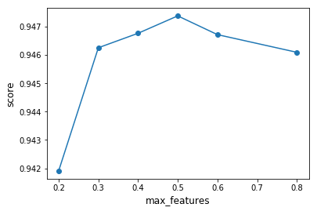

```python
# Check the influence of the parameter 'max_features' (other parameters are fixed) :
plt.figure()
plt.plot([0.2, 0.3, 0.4, 0.5, 0.6, 0.8],
         [0.94190686942, 0.946256998033, 0.946767665305, 0.947382357391436, 0.946720381298, 0.94609623241],
         'o-')
plt.xlabel('max_features', size=12)
plt.ylabel('score', size=12)
plt.show()
```

##### Influence of 'max_depth':

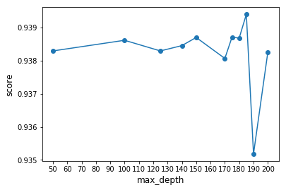

```python
# Check the influence of the parameter 'max_depth'(other parameters are fixed):
plt.figure()
plt.plot([50, 100, 125, 140, 150, 170, 175, 180, 185, 190, 200],
         [0.9382943713118475, 0.9386159025571191, 0.9382943713118475, 0.9384551369344832, 0.9387010137691028, 0.9380674080798911, 0.9387104705704342, 0.938682100166, 0.939400817067635, 0.935183083674, 0.9382565441065214],
         'o-')
plt.xticks(np.arange(50, 210, 10))
plt.xlabel('max_depth', size=12)
plt.ylabel('score', size=12)
plt.show()
```

##### Influence of 'min_samples_leaf ':

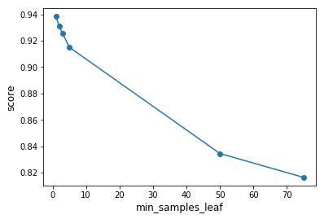

```python
# Check the influence of the parameter 'min_samples_leaf' (other parameters are fixed):
plt.figure()
plt.plot([1, 2, 3, 5, 50, 75],
         [0.938370025722, 0.930814041458617, 0.9255276895142986, 0.9150400968376456, 0.8344114086851263, 0.8163110909366016],
         'o-')
plt.xlabel('min_samples_leaf', size=12)
plt.ylabel('score', size=12)
plt.show()
```

##### Influence of 'oob_score ':

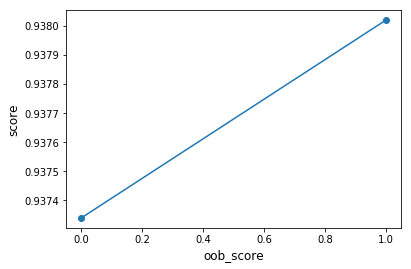

```python
# Check the influence of the parameter 'oob_score' (other parameters are fixed):
plt.figure()
plt.plot([True,False], [0.938020124073, 0.937339234377], '-o')
plt.xlabel('oob_score', size=12)
plt.ylabel('score', size=12)
plt.show()
```

##### Influence of 'n_estimators ':

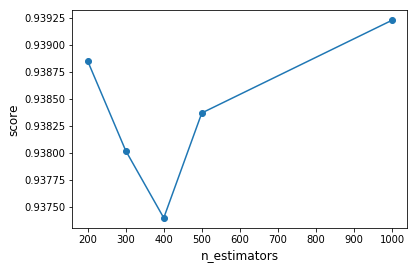

```python
# Check the influence of the parameter 'n_estimators' (other parameters are fixed):
plt.figure()
plt.plot([200, 300, 400, 500, 1000],
         [0.93885232259, 0.938020124073, 0.9373959751853533, 0.938370025722, 0.9392305946436678],
         'o-')
plt.xlabel('n_estimators', size=12)
plt.ylabel('score', size=12)
plt.show()
```

The list of the best parameters is :

- max_features = 0.5
- max_depth = 185
- min_samples_leaf = 1
- oob_score = True
- n_estimators = 1000

And we obtain a score with these parameters of 0.94821.

#### Extra Trees Classifier

Parameters tried :

- max_features : [0.9, None(take in account all the features)]
- max_depth : [165, 185]
- n_estimators : [50, 100, 300]

```python
# Example of the Training of Extra Trees Classifier with a set of parameters selected
ex = ExtraTreesClassifier(n_estimators=500,
                          bootstrap=True,
                          oob_score=True,
                          min_samples_leaf=1,
                          max_features=None,
                          random_state=55,
                          max_depth=175,
                          criterion='entropy',
                          n_jobs=-1)
ex.fit(X_train, y_train.ravel())
print("Training Score: %.5f" % ex.score(X_train, y_train))
```

```python
# Test the trained algorithm
y_test_predict = ex.predict(X_test)
score_test = accuracy_score(y_test, y_test_predict)
print("Test Score: %.5f" % score_test)
with open("Test_Score_Parameter_xxx.txt", "w") as out_file:
    out_file.write(str(score_test))
```

##### Influence of 'max_features ':

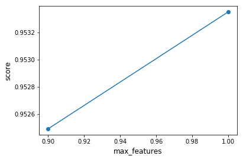

```python
# Check the influence of the parameter 'max_features' (other parameters are fixed):
plt.figure()
plt.plot([0.9, 1.0],
         [0.95249, 0.95335],
         'o-')
plt.xlabel('max_features', size=12)
plt.ylabel('score', size=12)
plt.show()
```

##### Influence of 'max_depth ':

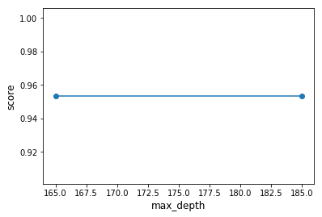

```python
# Check the influence of the parameter 'max_depth' (other parameters are fixed):
plt.figure()
plt.plot([165, 185],
         [0.95335, 0.95335],
         'o-')
plt.xlabel('max_depth', size=12)
plt.ylabel('score', size=12)
plt.show()
```

##### Influence of 'n_estimators ':

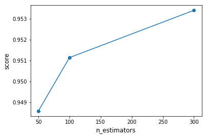

```python
# Check the influence of the parameter 'n_estimators' (other parameters are fixed):
plt.figure()
plt.plot([50, 100, 300],
         [0.94859 , 0.95114, 0.95340],
         'o-')
plt.xlabel('n_estimators', size=12)
plt.ylabel('score', size=12)
plt.show()
```

The list of the best parameters is :

- max_features = None (take in account all the features)
- max_depth = 185
- n_estimators = 300

And we obtain a score with these parameters of 0.95413.

We decide to choose the Extra Trees Classifier to do the final prediction on the Test dataset with the best parameters from our Crossvalidation step.

### Final Prediction on Test Dataset

```python
# We are getting the best parameters from our CrossValidation step and train again our algorithm in the whole train dataset:

# Change values of our data variables
X_train = train_df.iloc[:, :-1].values
y_train = train_df.iloc[:, -1:].values
X_test = test_df.values

# Train again our algorithm on the whole Train dataset:
ex_final = ExtraTreesClassifier(n_estimators=300,
                                bootstrap=True,
                                oob_score=True,
                                min_samples_leaf=1,
                                max_features=None,
                                max_depth = 185,
                                random_state=55,
                                criterion='entropy',
                                n_jobs=-1)
ex_final.fit(X_train, y_train.ravel())
print("Training Score: %.5f" % ex_final.score(X_train, y_train))
```

```python
# Make a copy of the test-set.csv file
temp = test_df.copy()

# Run Predictions on test-set.csv
temp['Cover_Type'] = ex_final.predict(X_test)

# Create Submissions csv file
temp = temp['Cover_Type']
temp.to_csv('SubmissionFile.csv', header=True)
```